# NORMAL DISTRIBUTION

It is a special kind of density curve that is bell shaped that's the reason we call Normal distribution as BELL CURVE or NORMAL CURVE.

It describe the tendency of data to cluster around the center ( i.e, Mu --> which is always located at center)

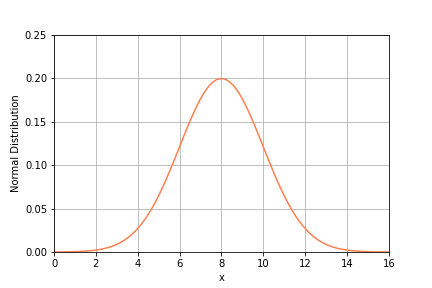

Based on the mu for any normal distribution we can say that some data point falls below

the mean and some data point falls above the mean however most of the data point falls near mean

Normal distributions depends on two ( population mean , population standard deviation)

- **Population mean** : This tells the position of the Normal Distribution Increase the mean curve moves to the RIGHT Decrease the mean curve moves to the LEFT this happens because data is always clusted to be clustered around mean
- **Population Standard Deviation** : This tells the spread of the distribution  
  Increase the SD the spread would be large Decrease the SD the spread would be small

  NOTE : when spread Increases the curve gets flatter and spread Decreases the curve gets taller

  REASON : Normal Distribution is a density curve and total area of any density curve must be equal to 1, so changes in width must effects on changes in height and vice versa

IMPORTANT POINTS OF NORMAL DISTRIBUTION

- Normal distribution is Unimodal : which means it has only one peak
- Normal Curve is symmetric : which means when we cut the distribution we get two equal halfs
- X ~ N ( mu , SD ) X follow a normal distribution which has MU with SD

# 68 95 99.7 EMPIRICAL RULE

Assume the same example we have taken in Statistical distribution measuring the height of people with MU = 5.5 and SD = 0.5

so with in 1-SD away from mean it contains area of 68%, with this we could say that aroung 68% of people falls between 5ft - 6ft tall

so with in 2-SD away from mean it contains area of 95%, with this we could say that around 95% of people falls between 4.5ft - 6.5ft tall

NOTE : we can extend to 4-SD , 5-SD , 6-SD .... as normal distribution curve never touches X-axis however the area containing in these regions are very small

This rule works for any Normal distribution no matter what shape it is

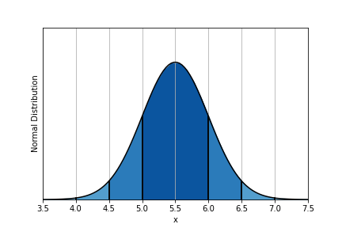

# General example :

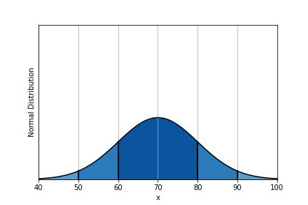